# PA1_template

JWillis

Saturday, July 18, 2015

This R Markdown document presents the results of Coursera Reproducible Research Peer Assessment 1 assignment, which interprets data about personal movement. This analysis is done in multiple parts. The analyzed data contains the number of steps taken by an individual over a two-month period. The steps were collected within five-minute intervals and missing values were represented as NA. The data contains 17,568 observations in a CSV file.

In this document, echo is set to TRUE so peer assessors may easily view the code used.

DATA LOADING & PRE-PROCESSING - These preliminary actions load the data and perform any needed pre-processing of the data to ensure it is easily analyzable. The data file is available locally. The variables are “steps”, “date”, “interval”."

```r
        dataIn <- data.frame()
        dataIn <- read.csv("./activity.csv", colClasses = "character")

        ## convert steps & integer variables to numeric types from character &
        ## convert date variable to date type from character
        dataIn$steps <- as.numeric(dataIn$steps)
        dataIn$interval <- as.numeric(dataIn$interval)
        dataIn$date <- as.Date(dataIn$date)

        ## check structure & summary of data
        str(dataIn)
```

```
## 'data.frame':    17568 obs. of  3 variables:
##  $ steps   : num  NA NA NA NA NA NA NA NA NA NA ...
##  $ date    : Date, format: "2012-10-01" "2012-10-01" ...
##  $ interval: num  0 5 10 15 20 25 30 35 40 45 ...
```

```r
        summary(dataIn)
```

```
##      steps             date               interval
##  Min.   :  0.00   Min.   :2012-10-01   Min.   :   0.0
##  1st Qu.:  0.00   1st Qu.:2012-10-16   1st Qu.: 588.8
##  Median :  0.00   Median :2012-10-31   Median :1177.5
##  Mean   : 37.38   Mean   :2012-10-31   Mean   :1177.5
##  3rd Qu.: 12.00   3rd Qu.:2012-11-15   3rd Qu.:1766.2
##  Max.   :806.00   Max.   :2012-11-30   Max.   :2355.0
##  NA's   :2304
```

QUESTION 1 - What is the mean total number of steps per day? The histogram shows the mean total number of steps per day over the 61-day period. The individual’s total step count per day varied widely with no particular trend. The individual’s highest step count per day occurred near the end of November, a traditional holiday period in the US. The histogram is also annotated with the cumulative mean and the cumulative median of the total number of steps. NA values were ignored in this representation.

```r
        library(plyr)
        library(dplyr)
```

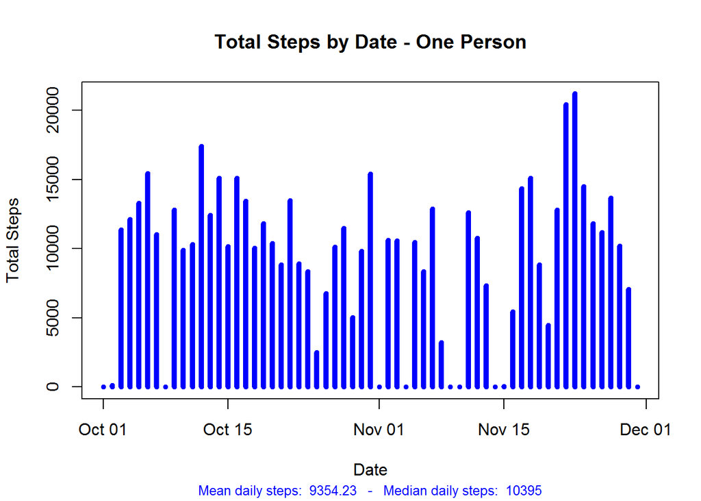

```r
        dataBySum <- data.frame

        dataByDate <- group_by(dataIn, date)
        dataBySum <- summarise(dataByDate, sumSteps = sum(steps, na.rm=TRUE))

        ## calculate the mean & median of the daily step sums, ignoring NAs
        sumStepMean <- round(mean(dataBySum$sumSteps, na.rm=TRUE), digits=2)
        sumStepMedian <- median(dataBySum$sumSteps, na.rm=TRUE)

        ## plot a histogram of the total number of steps per day
        ## include the mean & median daily steps on the plot for easy reference
        with(dataBySum, plot(date, sumSteps, type="h", col="blue",
                              lwd = 5,
                              xlab="Date",
                              ylab="Total Steps",
                              main="Total Steps by Date - One Person",
                              sub= paste(
                                      "Mean daily steps: ", sumStepMean,
                                      "  -   Median daily steps: ",
                                         sumStepMedian),
                             col.sub = "blue", cex.sub = 0.8))
```

QUESTION 2 - What is the average daily activity pattern? The average daily activity pattern is presented in a time-series diagram that shows averaged values for the individual’s steps during the various five-minute intervals in a day. The intervals may be read as 24-hour clock times. The data shows a clear maximum activity time around 0835 (8:35 am) and an inferred sleep period from approximately 2200 (10:00 pm) to 0500 (5:00 am). The time-series is also annotated with the interval with the highest average step count and that step count. NA values were ignored in this representation.

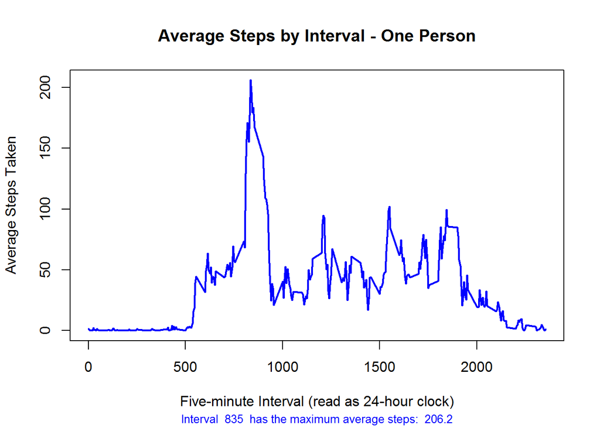

```r
        library(plyr)
        library(dplyr)

        dataByInterval <- data.frame()
        dataMeanByInterval <- data.frame()

        ## group data by interval saving intermediate step & ignoring NAs
        dataByInterval <- group_by(dataIn, interval)
        dataMeanByInterval <- summarise(dataByInterval,
                                        meanSteps = mean(steps, na.rm=TRUE))

        ## calculate the max mean steps, ignoring NAs
        maxSteps <- round(max(dataMeanByInterval$meanSteps, na.rm=TRUE), digits=1)

        ## calculate the max mean step sum interval
        maxIntervalRow <- which.max(dataMeanByInterval$meanSteps)
        maxInterval <- dataMeanByInterval$interval[maxIntervalRow]

        ## plot a time series of the total number of steps per interval number
        ## also annotate the plot with the interval with the max mean steps &
        ## the max number of steps
        with(dataMeanByInterval, plot(interval, meanSteps, type="l", col="blue",
                lwd = 2,
                xlab="Five-minute Interval (read as 24-hour clock)",
                ylab="Average Steps Taken",
                main="Average Steps by Interval - One Person",
                sub= paste("Interval ", maxInterval,
                           " has the maximum average steps: ",
                           maxSteps),col.sub = "blue", cex.sub = 0.8))
```

QUESTION 3 - What does this data look like with input for missing values? The number of missing values (steps = NA) is calculated and shown as the total number and as a percentage. The missing values are then replaced with the average increment step value. This filled in the low levels of steps data, and resulted in a higher mean step count. The median step value remained the same.

```r
        library(plyr)
        library(dplyr)

        dataByDate <- data.frame()
        dataBySum <- data.frame()
        dataByIntervalNoNA <- data.frame()
        dataMeanByIntervalNoNA <- data.frame()
        dataInNoNA <- data.frame()

        ## instantiate dataInNoNA to dataIn so can replace NAs in it
        dataInNoNA <- dataIn

        ## Calculate & report the total number of missing values
        numNARows <- nrow(dataIn[is.na(dataIn$steps), ])
        numTotalRows <- nrow(dataIn)
        percentNA <- round((numNARows*100 / numTotalRows), digits=1)
        print(paste("This data contains", numNARows,
                    "NA steps observations of", numTotalRows,
                    "total steps observations (", percentNA, "%)"))
```

```
## [1] "This data contains 2304 NA steps observations of 17568 total steps observations ( 13.1 %)"
```

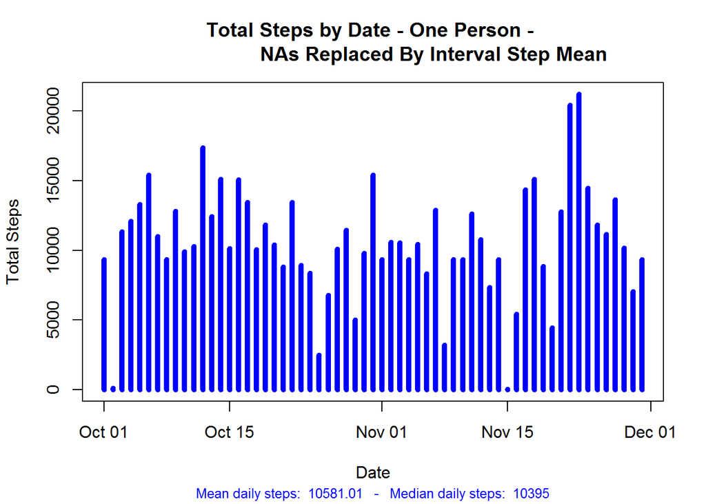

```r
        dataByDate <- group_by(dataIn, date)
        dataBySum <- summarise(dataByDate, sumSteps = sum(steps, na.rm=TRUE))

        ## calculate the mean of the daily step sums, ignoring NAs
        sumStepMean <- round(mean(dataBySum$sumSteps, na.rm=TRUE), digits=2)

        ## normalize the daily step sum mean to a single five-minute interval
        intervalStepMean <- sumStepMean/(24*12)

        ## replace NAs with intervalStepMean
        dataInNoNA$steps[is.na(dataInNoNA$steps)] <- intervalStepMean

        ## group and summarize so can find the sum
        dataByDateNoNA <- group_by(dataInNoNA, date)
        dataBySumNoNA <- summarise(dataByDateNoNA,
                                   sumSteps = sum(steps, na.rm=TRUE))


## calculate the mean & median of the daily step sums, ignoring NAs
        sumStepMeanN <- round(mean(dataBySumNoNA$sumSteps, na.rm=TRUE), digits=2)
        sumStepMedianN <- median(dataBySumNoNA$sumSteps, na.rm=TRUE)

        ## plot a histogram of the total number of steps per day
        ## include the mean & median daily steps on the plot for easy reference
        with(dataBySumNoNA, plot(date, sumSteps, type="h", col="blue",
                lwd = 5,
                xlab="Date",
                ylab="Total Steps",
                main="Total Steps by Date - One Person -
                     NAs Replaced By Interval Step Mean",
                sub= paste( "Mean daily steps: ", sumStepMeanN,
                            "  -   Median daily steps: ", sumStepMedianN),
                            col.sub = "blue", cex.sub = 0.8))
```

```r
        library(plyr)
        library(dplyr)
        library(lattice)
        dataByDate <- data.frame()
        dataBySum <- data.frame()
        dataByIntervalNoNA <- data.frame()
        dataMeanByIntervalNoNA <- data.frame()
        dataInNoNA <- data.frame()

        ## instantiate dataInNoNA to dataIn so can replace NAs in it
        dataInNoNA <- dataIn

        dataByDate <- group_by(dataIn, date)
        dataBySum <- summarise(dataByDate, sumSteps = sum(steps, na.rm=TRUE))

        ## calculate the mean of the daily step sums, ignoring NAs
        sumStepMean <- round(mean(dataBySum$sumSteps, na.rm=TRUE), digits=2)

        ## normalize the daily step sum mean to a single five-minute interval
        intervalStepMean <- sumStepMean/(24*12)

        ## replace NAs with intervalStepMean
        dataInNoNA$steps[is.na(dataInNoNA$steps)] <- intervalStepMean

        ## mutate to add dayType (weekday or weekend)
        ## then group and summarize
        dataByIntervalNoNA <- mutate(dataInNoNA, dayType =
                              ifelse((weekdays(date) == "Saturday" |
                                     weekdays(date) == "Sunday"), "weekend",
                                    "weekday"))

        dataMeanByIntervalNoNA <- group_by(dataByIntervalNoNA, interval,
                                           dayType) %>%
                                  summarise(meanSteps = mean(steps))
```

[figure not shown]

```r
        ## plot a time series of the mean number of steps per interval number

library(ggplot2)
        ## Weekday plot
        p1 <- ggplot(dataMeanByIntervalNoNA, aes(x=interval, y=meanSteps,
                        group    ="weekday")) +  geom_line() +
                        ggtitle("Weekday Average Steps by Interval")

        ## Weekend plot
        p2 <- ggplot(dataMeanByIntervalNoNA, aes(x=interval, y=meanSteps,
                        group="weekend")) + geom_line() +
                        ggtitle("Weekend Average Steps by Interval")

library(grid)
        ## print the plots
        pushViewport(viewport(layout = grid.layout(2, 1)))
        print(p1, vp = viewport(layout.pos.row = 1, layout.pos.col = 1))
        print(p2, vp = viewport(layout.pos.row = 2, layout.pos.col = 1))
```

- End of document -